# House Prediction

## Quick look at the dataset

First we read in our data:

```r
#stringsAsFactors is used here to be able later to convert non numerical to numerical
training.set <- read.csv("train.csv", stringsAsFactors=FALSE)
testing.set <- read.csv("test.csv", stringsAsFactors=FALSE)
```

Overview on the data

```r
head(training.set)
```

|  | Id | MSSubClass | MSZoning | LotFrontage | LotArea | Street | Alley | LotShape | LandContour | Utilities | LotConfig | LandSlope | Neighborhood | Condition1 | Condition2 | BldgType | HouseStyle | OverallQual | OverallCond | YearBuilt | YearRemodAdd | RoofStyle | RoofMatl | Exterior1st | Exterior2nd | MasVnrType | MasVnrArea | ExterQual | ExterCond | … |
| --- | --- | --- | --- | --- | --- | --- | --- | --- | --- | --- | --- | --- | --- | --- | --- | --- | --- | --- | --- | --- | --- | --- | --- | --- | --- | --- | --- | --- | --- | --- |
| 1 | 1 | 60 | RL | 65 | 8450 | Pave | NA | Reg | Lvl | AllPub | Inside | Gtl | CollgCr | Norm | Norm | 1Fam | 2Story | 7 | 5 | 2003 | 2003 | Gable | CompShg | VinylSd | VinylSd | BrkFace | 196 | Gd | TA | … |
| 2 | 2 | 20 | RL | 80 | 9600 | Pave | NA | Reg | Lvl | AllPub | FR2 | Gtl | Veenker | Feedr | Norm | 1Fam | 1Story | 6 | 8 | 1976 | 1976 | Gable | CompShg | MetalSd | MetalSd | None | 0 | TA | TA | … |
| 3 | 3 | 60 | RL | 68 | 11250 | Pave | NA | IR1 | Lvl | AllPub | Inside | Gtl | CollgCr | Norm | Norm | 1Fam | 2Story | 7 | 5 | 2001 | 2002 | Gable | CompShg | VinylSd | VinylSd | BrkFace | 162 | Gd | TA | … |
| 4 | 4 | 70 | RL | 60 | 9550 | Pave | NA | IR1 | Lvl | AllPub | Corner | Gtl | Crawfor | Norm | Norm | 1Fam | 2Story | 7 | 5 | 1915 | 1970 | Gable | CompShg | Wd Sdng | Wd Shng | None | 0 | TA | TA | … |
| 5 | 5 | 60 | RL | 84 | 14260 | Pave | NA | IR1 | Lvl | AllPub | FR2 | Gtl | NoRidge | Norm | Norm | 1Fam | 2Story | 8 | 5 | 2000 | 2000 | Gable | CompShg | VinylSd | VinylSd | BrkFace | 350 | Gd | TA | … |
| 6 | 6 | 50 | RL | 85 | 14115 | Pave | NA | IR1 | Lvl | AllPub | Inside | Gtl | Mitchel | Norm | Norm | 1Fam | 1.5Fin | 5 | 5 | 1993 | 1995 | Gable | CompShg | VinylSd | VinylSd | None | 0 | TA | TA | … |

## Handle non numerical columns

```r
#this function convert all the data to numeric
handle_Non_Numerical_columns <- function(data){

#for each field or column
for (field in 1:NCOL(data)){
      if (!is.numeric(data[1, field])){

        allValues = c()
        #creating a set of all the values of the column
        #for each value in the field
        for (value in data[, field]){
          if ((!value %in% allValues) && !is.na(value)){
            allValues = c(allValues, value)
          }
        }


        #browse the column and substitute the values by their numerical corresponding
        #for each value in the field
        pos = 1
        for (value in data[, field]){
          #the function match returns the position of value in the list allValues
          data[pos, field] = match(value, allValues)
          pos = pos + 1

        }

      }
#convert the column in numeric
data[,field] = as.numeric(data[,field])
}

return(data)
}
training.set = handle_Non_Numerical_columns(training.set)
testing.set = handle_Non_Numerical_columns(testing.set)
head(training.set)
```

|  | Id | MSSubClass | MSZoning | LotFrontage | LotArea | Street | Alley | LotShape | LandContour | Utilities | LotConfig | LandSlope | Neighborhood | Condition1 | Condition2 | BldgType | HouseStyle | OverallQual | OverallCond | YearBuilt | YearRemodAdd | RoofStyle | RoofMatl | Exterior1st | Exterior2nd | MasVnrType | MasVnrArea | ExterQual | ExterCond | … |
| --- | --- | --- | --- | --- | --- | --- | --- | --- | --- | --- | --- | --- | --- | --- | --- | --- | --- | --- | --- | --- | --- | --- | --- | --- | --- | --- | --- | --- | --- | --- |
| 1 | 1 | 60 | 1 | 65 | 8450 | 1 | NA | 1 | 1 | 1 | 1 | 1 | 1 | 1 | 1 | 1 | 1 | 7 | 5 | 2003 | 2003 | 1 | 1 | 1 | 1 | 1 | 196 | 1 | 1 | … |
| 2 | 2 | 20 | 1 | 80 | 9600 | 1 | NA | 1 | 1 | 1 | 2 | 1 | 2 | 2 | 1 | 1 | 2 | 6 | 8 | 1976 | 1976 | 1 | 1 | 2 | 2 | 2 | 0 | 2 | 1 | … |
| 3 | 3 | 60 | 1 | 68 | 11250 | 1 | NA | 2 | 1 | 1 | 1 | 1 | 1 | 1 | 1 | 1 | 1 | 7 | 5 | 2001 | 2002 | 1 | 1 | 1 | 1 | 1 | 162 | 1 | 1 | … |
| 4 | 4 | 70 | 1 | 60 | 9550 | 1 | NA | 2 | 1 | 1 | 3 | 1 | 3 | 1 | 1 | 1 | 1 | 7 | 5 | 1915 | 1970 | 1 | 1 | 3 | 3 | 2 | 0 | 2 | 1 | … |
| 5 | 5 | 60 | 1 | 84 | 14260 | 1 | NA | 2 | 1 | 1 | 2 | 1 | 4 | 1 | 1 | 1 | 1 | 8 | 5 | 2000 | 2000 | 1 | 1 | 1 | 1 | 1 | 350 | 1 | 1 | … |
| 6 | 6 | 50 | 1 | 85 | 14115 | 1 | NA | 2 | 1 | 1 | 1 | 1 | 5 | 1 | 1 | 1 | 3 | 5 | 5 | 1993 | 1995 | 1 | 1 | 1 | 1 | 2 | 0 | 2 | 1 | … |

## Dealing with the NAs

At this point, all our fields are numerical but we still have a lot of NAs values. to solve this we will: first test for NA and NaN using is.na and is.nan. After what we will use a common way to deal with these invalid numbers wich is to replace them with the mean or median of the other available data.

```r
#this function replaces all NAs of the dataset by the mean or median of the coresponding field
Replacing.NAs <- function(data){
    for (field in 1:NCOL(data)){
          #compute the mean
              field.mean <- median(data[,field], na.rm=TRUE)
          #substitute all the NAs by the mean
               data[is.na(data[,field]), field] <- field.mean

    }
return(data)
}
training.set = Replacing.NAs(training.set)
testing.set = Replacing.NAs(testing.set)
training.set.full = Replacing.NAs(training.set)
testing.set.full = Replacing.NAs(testing.set)
head(training.set)
```

|  | Id | MSSubClass | MSZoning | LotFrontage | LotArea | Street | Alley | LotShape | LandContour | Utilities | LotConfig | LandSlope | Neighborhood | Condition1 | Condition2 | BldgType | HouseStyle | OverallQual | OverallCond | YearBuilt | YearRemodAdd | RoofStyle | RoofMatl | Exterior1st | Exterior2nd | MasVnrType | MasVnrArea | ExterQual | ExterCond | … |
| --- | --- | --- | --- | --- | --- | --- | --- | --- | --- | --- | --- | --- | --- | --- | --- | --- | --- | --- | --- | --- | --- | --- | --- | --- | --- | --- | --- | --- | --- | --- |
| 1 | 1 | 60 | 1 | 65 | 8450 | 1 | 1 | 1 | 1 | 1 | 1 | 1 | 1 | 1 | 1 | 1 | 1 | 7 | 5 | 2003 | 2003 | 1 | 1 | 1 | 1 | 1 | 196 | 1 | 1 | … |
| 2 | 2 | 20 | 1 | 80 | 9600 | 1 | 1 | 1 | 1 | 1 | 2 | 1 | 2 | 2 | 1 | 1 | 2 | 6 | 8 | 1976 | 1976 | 1 | 1 | 2 | 2 | 2 | 0 | 2 | 1 | … |
| 3 | 3 | 60 | 1 | 68 | 11250 | 1 | 1 | 2 | 1 | 1 | 1 | 1 | 1 | 1 | 1 | 1 | 1 | 7 | 5 | 2001 | 2002 | 1 | 1 | 1 | 1 | 1 | 162 | 1 | 1 | … |
| 4 | 4 | 70 | 1 | 60 | 9550 | 1 | 1 | 2 | 1 | 1 | 3 | 1 | 3 | 1 | 1 | 1 | 1 | 7 | 5 | 1915 | 1970 | 1 | 1 | 3 | 3 | 2 | 0 | 2 | 1 | … |
| 5 | 5 | 60 | 1 | 84 | 14260 | 1 | 1 | 2 | 1 | 1 | 2 | 1 | 4 | 1 | 1 | 1 | 1 | 8 | 5 | 2000 | 2000 | 1 | 1 | 1 | 1 | 1 | 350 | 1 | 1 | … |
| 6 | 6 | 50 | 1 | 85 | 14115 | 1 | 1 | 2 | 1 | 1 | 1 | 1 | 5 | 1 | 1 | 1 | 3 | 5 | 5 | 1993 | 1995 | 1 | 1 | 1 | 1 | 2 | 0 | 2 | 1 | … |

Remove the camp Id from the Data since it’s useless in findind the price of the house. then computing the log(saleprice) cause it’s normally distributed and then it’s better for linear regression

```r
#training.set <- subset(training.set, select = -Id )
#testing.set <- subset(testing.set, select = -Id )
#select variables that be used for model
model_var <- c('SalePrice',
                'OverallQual','OverallCond','YearBuilt','ExterCond',
                'TotalBsmtSF','HeatingQC',
                'CentralAir','GrLivArea','BedroomAbvGr','KitchenAbvGr',
                'TotRmsAbvGrd','Fireplaces',
                'GarageArea','OpenPorchSF','PoolArea',
                 'YrSold')
training.set <- training.set[, model_var]
training.set$LogSalePrice = log(training.set$SalePrice)
head(training.set)
```

|  | SalePrice | OverallQual | OverallCond | YearBuilt | ExterCond | TotalBsmtSF | HeatingQC | CentralAir | GrLivArea | BedroomAbvGr | KitchenAbvGr | TotRmsAbvGrd | Fireplaces | GarageArea | OpenPorchSF | PoolArea | YrSold | LogSalePrice |
| --- | --- | --- | --- | --- | --- | --- | --- | --- | --- | --- | --- | --- | --- | --- | --- | --- | --- | --- |
| 1 | 208500 | 7 | 5 | 2003 | 1 | 856 | 1 | 1 | 1710 | 3 | 1 | 8 | 0 | 548 | 61 | 0 | 2008 | 12.24769 |
| 2 | 181500 | 6 | 8 | 1976 | 1 | 1262 | 1 | 1 | 1262 | 3 | 1 | 6 | 1 | 460 | 0 | 0 | 2007 | 12.10901 |
| 3 | 223500 | 7 | 5 | 2001 | 1 | 920 | 1 | 1 | 1786 | 3 | 1 | 6 | 1 | 608 | 42 | 0 | 2008 | 12.31717 |
| 4 | 140000 | 7 | 5 | 1915 | 1 | 756 | 2 | 1 | 1717 | 3 | 1 | 7 | 1 | 642 | 35 | 0 | 2006 | 11.84940 |
| 5 | 250000 | 8 | 5 | 2000 | 1 | 1145 | 1 | 1 | 2198 | 4 | 1 | 9 | 1 | 836 | 84 | 0 | 2008 | 12.42922 |
| 6 | 143000 | 5 | 5 | 1993 | 1 | 796 | 1 | 1 | 1362 | 1 | 1 | 5 | 0 | 480 | 30 | 0 | 2009 | 11.87060 |

Let’s do the linear regression

```r
#partition data for cross validation
set.seed(123)
#taking randomly 0.8(80%) of the observation for training the data and 20% for cross validating
train.index <- sample(c(1:dim(training.set)[1]), dim(training.set)[1]*0.8)
model_lin_train = training.set[train.index,]
model_lin_valid <- training.set[-train.index,]
model_lin_train <- subset(model_lin_train, select = -SalePrice)
linreg <- lm(LogSalePrice~., data = model_lin_train)
sm <- summary(linreg)
sm
```

```
Call:
lm(formula = LogSalePrice ~ ., data = model_lin_train)

Residuals:
     Min       1Q   Median       3Q      Max
-2.29540 -0.07035  0.00218  0.07997  0.58258

Coefficients:
               Estimate Std. Error t value Pr(>|t|)
(Intercept)   7.530e+00  6.921e+00   1.088 0.276818
OverallQual   7.727e-02  5.578e-03  13.852  < 2e-16 ***
OverallCond   5.207e-02  4.893e-03  10.641  < 2e-16 ***
YearBuilt     3.420e-03  2.352e-04  14.537  < 2e-16 ***
ExterCond    -7.990e-03  1.112e-02  -0.719 0.472499
TotalBsmtSF   1.196e-04  1.328e-05   9.009  < 2e-16 ***
HeatingQC    -1.831e-02  5.761e-03  -3.178 0.001521 **
CentralAir   -7.327e-02  2.155e-02  -3.400 0.000697 ***
GrLivArea     2.228e-04  1.901e-05  11.720  < 2e-16 ***
BedroomAbvGr -9.988e-03  8.062e-03  -1.239 0.215658
KitchenAbvGr -6.107e-02  2.358e-02  -2.590 0.009708 **
TotRmsAbvGrd  1.644e-02  6.024e-03   2.729 0.006459 **
Fireplaces    6.040e-02  8.400e-03   7.191 1.16e-12 ***
GarageArea    2.397e-04  2.827e-05   8.480  < 2e-16 ***
OpenPorchSF   9.575e-05  7.766e-05   1.233 0.217856
PoolArea     -3.658e-04  1.051e-04  -3.482 0.000517 ***
YrSold       -1.753e-03  3.447e-03  -0.508 0.611207
---
Signif. codes:  0 ‘***’ 0.001 ‘**’ 0.01 ‘*’ 0.05 ‘.’ 0.1 ‘ ’ 1

Residual standard error: 0.1549 on 1151 degrees of freedom
Multiple R-squared:  0.8544,    Adjusted R-squared:  0.8524
F-statistic: 422.3 on 16 and 1151 DF,  p-value: < 2.2e-16
```

Let’s do the cross validation by using the model to do prediction on the other 20% of the data

```r
library(forecast)
SalePrice1 <- predict(linreg, newdata = model_lin_valid)
#SalePrice1 <- data.frame(SalePrice1)
#head(SalePrice1)
residuals <- model_lin_valid$LogSalePrice - SalePrice1
linreg_pred <- data.frame("Predicted" = SalePrice1, "Actual" = model_lin_valid$LogSalePrice, "Residual" = residuals)
View(accuracy(SalePrice1, model_lin_valid$LogSalePrice))
```

Now let’s use the model predict the House prices of the testing set

```r
SalePrice2 <- predict(linreg, newdata = testing.set)
SalePrice <- exp(SalePrice2)
```

product the submission file

```r
y<-cbind(data.frame("Id"=1461:(1460+nrow(testing.set)), SalePrice))
head(y)

# Save prediction to My_Submission.csv
write.csv(y,file="My_Submission.csv", quote = FALSE, row.names = FALSE)
```

Let’t use the XGBoost tool to get a better model

```r
library(xgboost)
# load data
# fit model
bst <- xgboost(data = data.matrix(model_lin_train), label = model_lin_train$LogSalePrice, max.depth = 2, eta = 0.3, nround = 30, nthread = 2, objective = "reg:linear")
# predict
pred <- predict(bst, data.matrix(model_lin_valid))
residuals <- model_lin_valid$LogSalePrice - pred
xgb_pred <- data.frame("Predicted" = pred, "Actual" = model_lin_valid$LogSalePrice, "Residual" = residuals)
View(accuracy(pred, model_lin_valid$LogSalePrice))
```

```r
FullData.set <- rbind(training.set.full[,-81],testing.set.full)
train.rf <- cbind(FullData.set[1:1460,],training.set.full[,81])
test.rf <- FullData.set[-(1:1460),-81]
names(test.rf) = names(testing.set)
names(train.rf) = names(training.set)
```

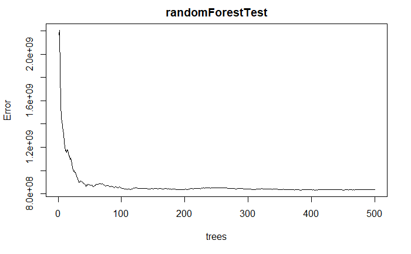

```r
library(randomForest)
randomForestTest <- randomForest(SalePrice ~ ., data=train.rf,ntree=500)
plot(randomForestTest)
```

```r
prediction.RandomForest <- predict(randomForestTest,test.rf,type="response")
```

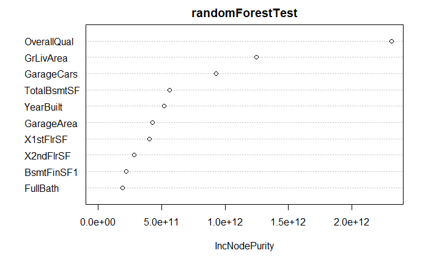

```r
varImpPlot(randomForestTest,n.var = 10)
```

```r
submit.randomforest <- cbind(test.rf$Id,prediction.RandomForest)
write.table(submit.randomforest,file="submissionRF.csv",sep=",",
            quote=FALSE,col.names=c("Id","SalePrice"),row.names=FALSE)
```

```r
library(corrplot)
library(Metrics)
library(randomForest)
```

```r
cor.par= cor(training.set, use = "everything")
png(height=1200, width=1500, pointsize=15, file="correlations.png")
corrplot(cor.par, method = "shade", type="upper", sig.level = 0.01, insig = "blank")
```

```r
train.II = training.set
```

```r
train.II$QualTime = train.II$OverallQual * train.II$YearBuilt
train.II$QualRemodTime = train.II$OverallQual * train.II$YearRemodAdd
train.II$QualBasement = train.II$OverallQual * train.II$TotalBsmtSF
train.II$QualBathrooms = train.II$OverallQual * train.II$FullBath
train.II$QualLivingArea = train.II$OverallQual * train.II$GrLivArea
train.II$QualExterior = train.II$OverallQual * train.II$ExterCond
```

Lets have a look at the data again

```r
png(height=1200, width=1500, pointsize=15, file="trainII.png")
corrplot(cor(train.II, use = "everything"), method = "shade", type="upper", sig.level = 0.01, insig = "blank")
```

```r
train.II$TotalArea = train.II$TotalBsmtSF + train.II$X1stFlrSF + train.II$X2ndFlrSF
train.II$QualTotalArea = train.II$OverallQual * train.II$TotalArea
```

RUNNING MODEL ON NEW DATASET

```r
train.index <- sample(c(1:dim(train.II)[1]), dim(train.II)[1]*0.8)
model_train = train.II[train.index,]
model_test <- train.II[-train.index,]
```

LINEAR MODEL

```r
set.seed(123)
lin_model = lm(SalePrice ~., data = model_train)
summary(lin_model)
```

[output not shown]

[output cut: 49 more lines]

```
SaleCondition  -6.529e+02  1.190e+03  -0.549 0.583446
QualTime        7.635e+01  4.288e+01   1.780 0.075277 .
QualRemodTime   2.293e+02  5.963e+01   3.845 0.000128 ***
QualBasement   -2.410e+01  1.289e+01  -1.871 0.061673 .
QualBathrooms   5.236e+03  1.955e+03   2.679 0.007506 **
QualLivingArea -1.167e+01  1.220e+01  -0.957 0.338879
QualExterior    2.106e+03  1.466e+03   1.437 0.150952
TotalArea              NA         NA      NA       NA
QualTotalArea   1.743e+01  1.260e+01   1.383 0.166863
---
Signif. codes:  0 ‘***’ 0.001 ‘**’ 0.01 ‘*’ 0.05 ‘.’ 0.1 ‘ ’ 1

Residual standard error: 31350 on 1082 degrees of freedom
Multiple R-squared:  0.8626,    Adjusted R-squared:  0.8518
F-statistic:  79.9 on 85 and 1082 DF,  p-value: < 2.2e-16
```

```r
prediction <- predict(lin_model, model_test, type="response")
```

```
prediction from a rank-deficient fit may be misleading
```

```r
pred_lm <- cbind(model_test, prediction)
pred_lm$log_prediction <- log(pred_lm$prediction)
pred_lm$log_SalePrice <- log(pred_lm$SalePrice)
rmse(pred_lm$log_SalePrice,pred_lm$log_prediction)
```

```
[1] 0.1744932
```

Run the same lm on the significan ones

```r
linear_sig = lm(SalePrice ~ LotArea+Condition2+OverallQual+OverallCond+YearRemodAdd+RoofMatl+BsmtFinSF1+BsmtFinSF2
                    +BsmtUnfSF +KitchenQual+GarageCars+WoodDeckSF +ScreenPorch +PoolQC+QualRemodTime , data=train.II)
```

```r
prediction <- predict(linear_sig, model_test, type="response")
pred_lm <- cbind(model_test, prediction)
pred_lm$log_prediction <- log(pred_lm$prediction)
pred_lm$log_SalePrice <- log(pred_lm$SalePrice)
rmse(pred_lm$log_SalePrice,pred_lm$log_prediction)
```

```
[1] 0.2180865
```

RANDOM FOREST

```r
rf_mod = randomForest(SalePrice~., data= model_train)
prediction <- predict(rf_mod, model_test)
pred_rf <- cbind(model_test, prediction)
pred_rf$log_prediction <- log(pred_rf$prediction)
pred_rf$log_SalePrice <- log(pred_rf$SalePrice)
rmse(pred_rf$log_SalePrice,pred_rf$log_prediction)
```

```
[1] 0.1297107
```